# Space Race Data Analysis

# Introduction

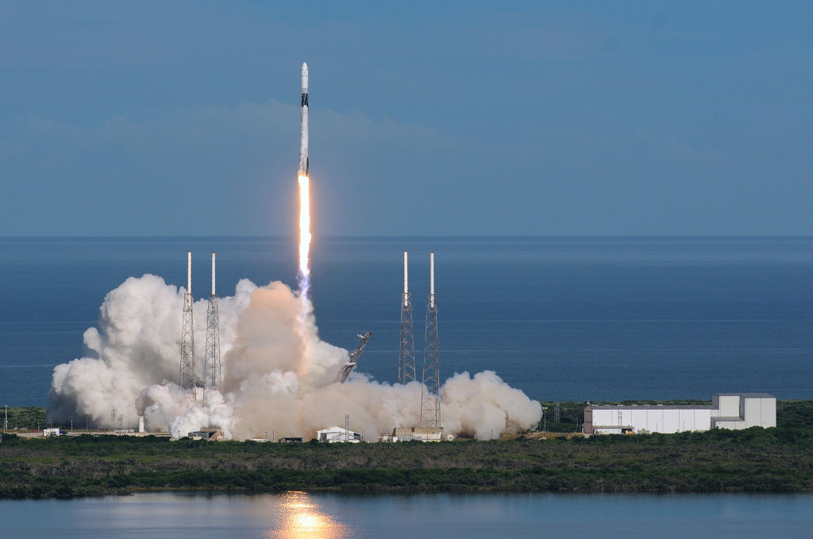

This dataset was scraped from [nextspaceflight.com](https://nextspaceflight.com/launches/past/?page=1) and includes all the space missions since the beginning of Space Race between the USA and the Soviet Union in 1957!

## Import Statements

```python
import numpy as np
import pandas as pd
import plotly.express as px
import matplotlib.pyplot as plt
import seaborn as sns
from iso3166 import countries
from datetime import datetime, timedelta
from IPython.display import Markdown, display
import re

pd.options.display.float_format = '{:,.2f}'.format
```

## Load the Data

```python
df_data = pd.read_csv('data/mission_launches.csv', index_col = False)
```

# Preliminary Data Exploration

- What is the shape of `df_data`?
- How many rows and columns does it have?
- What are the column names?
- Are there any NaN values or duplicates?

```python
print(df_data.shape)
print(df_data.columns)
```

```
(4324, 9)
Index(['Unnamed: 0.1', 'Unnamed: 0', 'Organisation', 'Location', 'Date',
       'Detail', 'Rocket_Status', 'Price', 'Mission_Status'],
      dtype='object')
```

## Data Cleaning - Check for Missing Values and Duplicates

Consider removing columns containing junk data.

```python
print(df_data.info())
df_data.drop(columns = ["Unnamed: 0.1", "Unnamed: 0"], inplace = True)
```

```
<class 'pandas.core.frame.DataFrame'>
RangeIndex: 4324 entries, 0 to 4323
Data columns (total 9 columns):
 #   Column          Non-Null Count  Dtype
---  ------          --------------  -----
 0   Unnamed: 0.1    4324 non-null   int64
 1   Unnamed: 0      4324 non-null   int64
 2   Organisation    4324 non-null   object
 3   Location        4324 non-null   object
 4   Date            4324 non-null   object
 5   Detail          4324 non-null   object
 6   Rocket_Status   4324 non-null   object
 7   Price           964 non-null    object
 8   Mission_Status  4324 non-null   object
dtypes: int64(2), object(7)
memory usage: 304.2+ KB
None
```

# Descriptive Statistics

## Number of Launches per Company

Create a chart that shows the number of space mission launches by organisation.

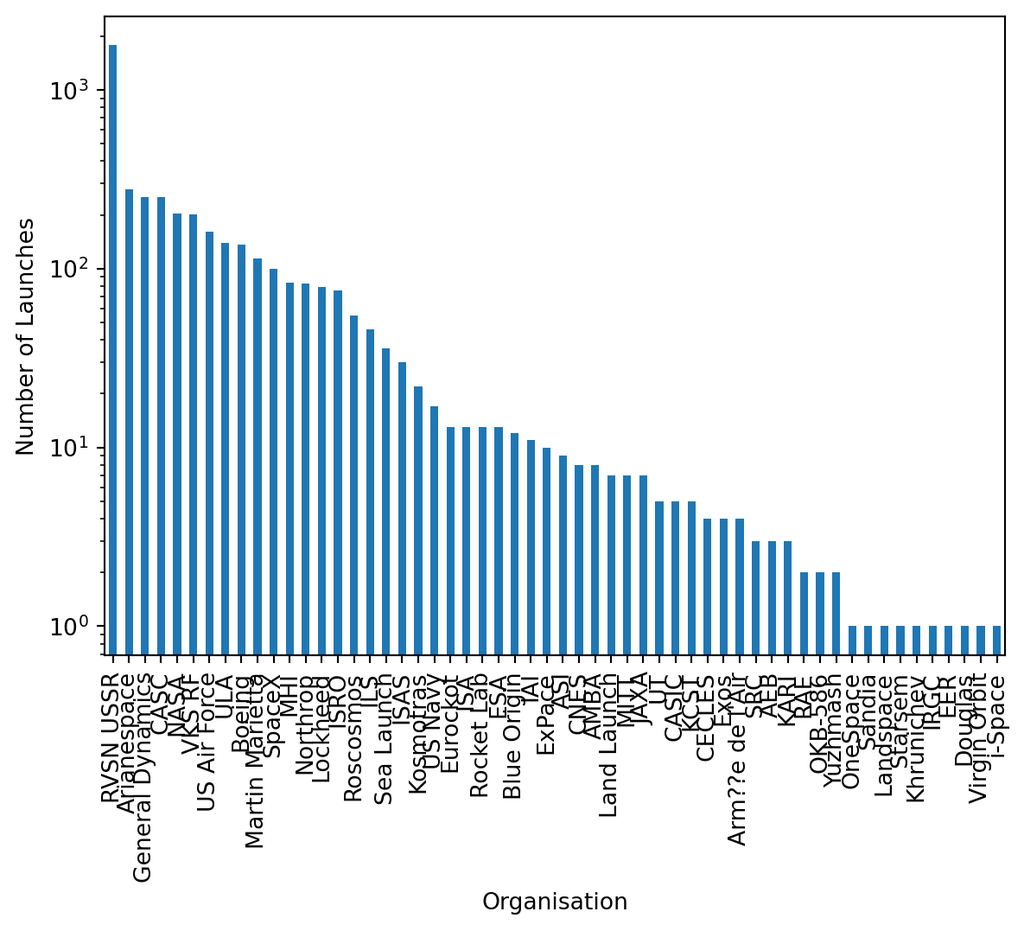

```python
launches_organization = df_data.value_counts("Organisation")
launches_organization.plot(kind = "bar", logy = True, ylabel = "Number of Launches")
plt.show()
```

# Number of Active versus Retired Rockets

How many rockets are active compared to those that are decomissioned?

```python
rocket_status = df_data.value_counts("Rocket_Status").to_frame()
rocket_status.reset_index(inplace = True)
rocket_status["Rocket_Status"] = rocket_status["Rocket_Status"].str.replace("Status", "")
display(Markdown(rocket_status.to_markdown(index = False)))
```

| Rocket_Status | count |
| --- | --- |
| Retired | 3534 |
| Active | 790 |

# Distribution of Mission Status

How many missions were successful? How many missions failed?

```python
mission_status = df_data.value_counts("Mission_Status").to_frame()
mission_status.reset_index(inplace = True)
display(Markdown(mission_status.to_markdown(index = False)))
```

| Mission_Status | count |
| --- | --- |
| Success | 3879 |
| Failure | 339 |
| Partial Failure | 102 |
| Prelaunch Failure | 4 |

# How Expensive are the Launches?

Create a histogram and visualise the distribution. The price column is given in USD millions (careful of missing values).

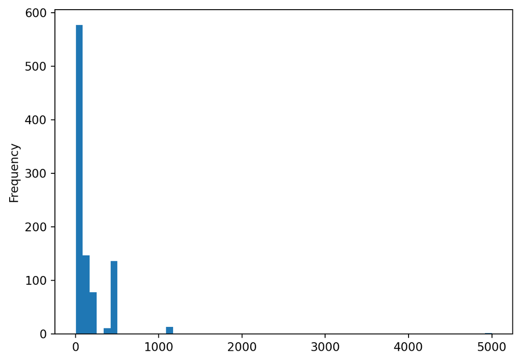

```python
df_data["Price"] = df_data["Price"].str.replace(",", "").astype("float")
plt.figure()
df_data["Price"].plot.hist(bins = 60)
plt.show()
```

# Use a Choropleth Map to Show the Number of Launches by Country

- Create a choropleth map using [the plotly documentation](https://plotly.com/python/choropleth-maps/)
- Experiment with [plotly’s available colours](https://plotly.com/python/builtin-colorscales/). I quite like the sequential colour `matter` on this map.
- You’ll need to extract a `country` feature as well as change the country names that no longer exist.

```python
df_data["country"] = [re.sub(r"(^.*)(, )([A-Za-z ]+$)", r"\3", location) for location in df_data["Location"]]
df_data.loc[df_data["country"] == "Shahrud Missile Test Site", "country"] = "Iran"
df_data.loc[df_data["country"] == "New Mexico", "country"] = "USA"
df_data.loc[df_data["country"] == "Yellow Sea", "country"] = "China"
df_data.loc[df_data["country"] == "Pacific Missile Range Facility", "country"] = "USA"
df_data.loc[df_data["country"] == "Pacific Ocean", "country"] = "USA"
df_data.loc[df_data["country"] == "Barents Sea", "country"] = "Russia"
df_data.loc[df_data["country"] == "Gran Canaria", "country"] = "Spain"
df_data.loc[df_data["country"] == "Russia", "country"] = "Russian Federation"
df_data.loc[df_data["country"] == "Iran", "country"] = "Iran, Islamic Republic of"
df_data.loc[df_data["country"] == "North Korea", "country"] = "Korea, Democratic People's Republic of"
df_data.loc[df_data["country"] == "South Korea", "country"] = "Korea, Republic of"


df_data["ISO"] = [countries.get(country).alpha3 for country in df_data["country"]]
launches_iso_country = df_data.groupby("ISO", as_index = False).size()
launches_iso_country.columns = ["iso_alpha", "Launches"]
df = px.data.gapminder().query("year==2007")

df = pd.merge(df, launches_iso_country, on = "iso_alpha")
fig = px.choropleth(df, locations="iso_alpha",
                    color="Launches",
                    hover_name="country", # column to add to hover information
                    color_continuous_scale=px.colors.sequential.OrRd)
fig.show()
```

[interactive chart not shown]

# Create a Plotly Sunburst Chart of the countries, organisations, and mission status.

```python
organization_detail = df_data.groupby(["country", "Organisation", "Mission_Status"], as_index = False).agg({"Price": pd.Series.count})
organization_detail.rename(columns = {"country": "Country", "Organisation": "Organization", "Mission_Status": "Status"}, inplace = True)
sb = px.sunburst(organization_detail, path = ["Country", "Organization", "Status"], values = "Price")
sb.show()
```

[interactive chart not shown]

# Analyse the Amount of Money Spent by Organisation per Launch

```python
money_spent = df_data.groupby("Organisation", as_index = False).agg({"Price": pd.Series.sum})
bar = px.bar(money_spent, x = "Organisation", y = "Price", labels = {"Price": "Price in millions of USD"})
bar.show()
```

[interactive chart not shown]

# Chart the Number of Launches per Year

```python
df_data["datetime"] = pd.to_datetime(df_data["Date"], format = "%a %b %d, %Y %H:%M %Z", errors = "coerce")
df_data.loc[df_data["datetime"].isna(), "datetime"] = pd.to_datetime(df_data[df_data["datetime"].isna()]["Date"], format = "%a %b %d, %Y")
df_data["year"] = df_data["datetime"].apply(lambda x: x.year)

launches_year = df_data.groupby("year", as_index = False).size()
lpy = px.scatter(launches_year, x = "year", y = "size", labels = {"size": "Number of Launches"}, trendline = "lowess", trendline_options = {"frac": 0.1})
lpy.show()
```

[interactive chart not shown]

# Chart the Number of Launches Month-on-Month until the Present

```python
df_data["month"] = df_data["datetime"].apply(lambda x: x.month)
launches_month = df_data.groupby("month", as_index = False).size()

lpm = px.scatter(launches_month, x = "month", y = "size", labels = {"size": "Number of Launches"}, trendline = "rolling", trendline_options = {"window": 3})
lpm.show()
```

[interactive chart not shown]

# How has the Launch Price varied Over Time?

Create a line chart that shows the average price of rocket launches over time.

```python
price_year = df_data.groupby("year", as_index = False)["Price"].mean()

ppy = px.line(price_year, x = "year", y = "Price", labels = {"Price": "Price in millions USD"})
ppy.show()
```

[interactive chart not shown]